# Multiple class classification

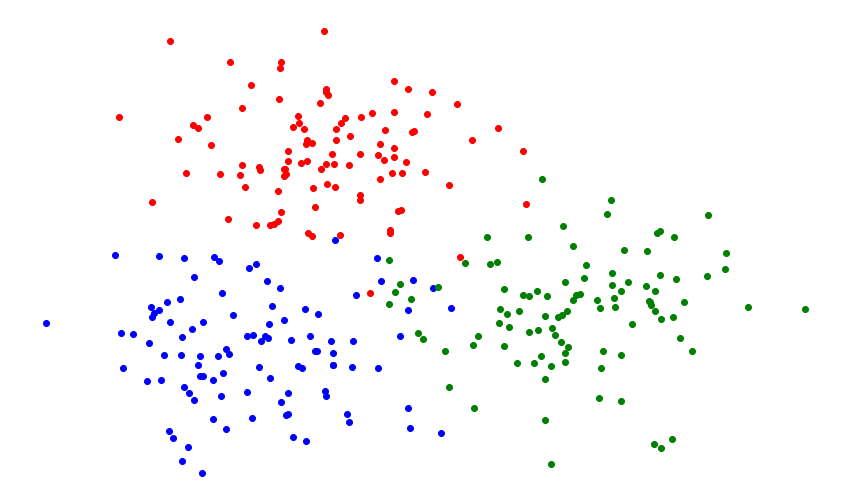

Q: Can we use 2 class case to classify multiple classes?

A: We can compare each 2 classes and thus decide the class ("one versus one")

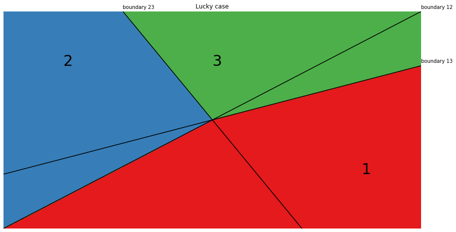

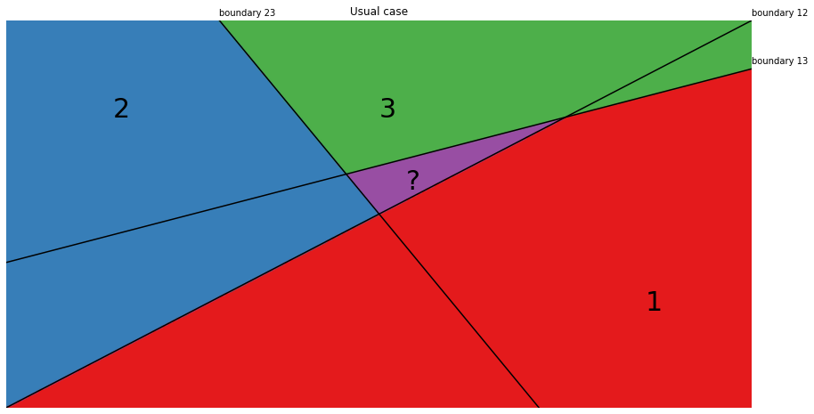

A: Use discriminator for each class(except the last one) of type "one versus the rest". If the given point is not from any class, it's from the last one.

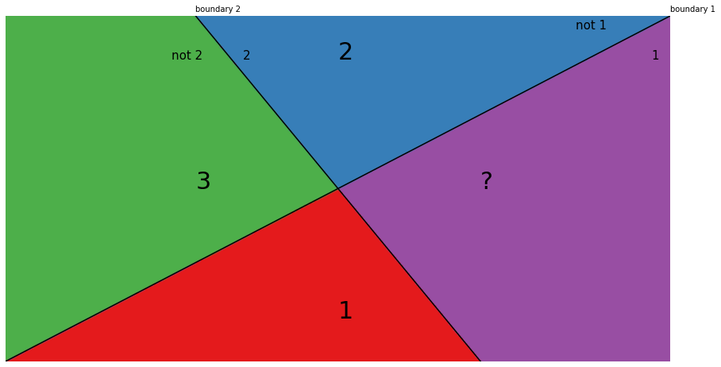

A: Let's have a line(not a decision boundary) $w$ for each class, and predict by largest $w^T\phi$.

So for classes $i$ and $j$ the decision will be maid by comparing $w_i^T\phi$ and $w_j^T\phi$. It's equivalent to compare $(w_i-w_j)^t\phi$ with $0$. So the decision boundary could be drawn from $w_i-w_j$ normal vector.

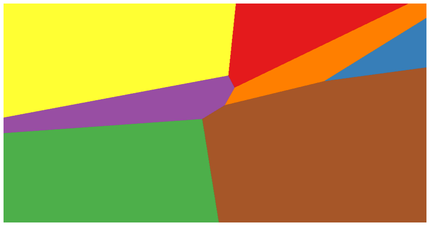

Recall: $$P(C_k|\phi)=\frac{P(\phi|C_k)\cdot P(C_k)}{\sum_{m=1}^MP(\phi|C_m)\cdot P(C_m)}=\frac{exp(\alpha_k)}{\sum_{m=1}^Mexp(\alpha_m)}$$

# Multiclass Logistic Regressuion

$$Likelihood = \prod_{n=1}^N P(\phi_n|C_{t_n}) = \prod_{n=1}^N \frac{exp(\alpha_{nt_n})}{\sum_{m=1}^M exp(\alpha_{nm})}$$

Where $\alpha_{nm} = w_m^T\phi_n$

$$y_{nm} \mathop{=}^{def} P(\phi_n|C_m)$$

$$Likelihood = \prod_{n=1}^N y_{nt_n}$$

Now, we will use one hot encoding for $t$ target vectors. So $t_{nm}$ will be 1 if $\phi_n$ is from $C_m$, and 0 otherwise.

$$Likelihood = \prod_{n=1}^N \prod_{m=1}^M y_{nm}^{t_nm}$$

$$Loss = -LogLikelihood = -\sum_{n=1}^N \sum_{m=1}^M t_{nm}\ln(y_{nm})$$

$$\nabla_{w_m} Loss = -\sum_{n=1}^N (y_{nm} - t_{nm})\phi_n$$

$$\nabla_{w_k}\nabla_{w_m} Loss = -\sum_{n=1}^N y_{nk}(I_{km} - y_{nm})\phi_n\phi_n^T$$

Where $I_{km}$ is 1 if $k = m$ and 0 otherwise.

The hessian matrix couls be constructed from those block matrices.

Note, that hessian matrix contains $(M\cdot D)^2$ elements, where $D$ is the number of dimensions. So, inversion complexity will be $\Omega((M\cdot D)^{4.5})$.

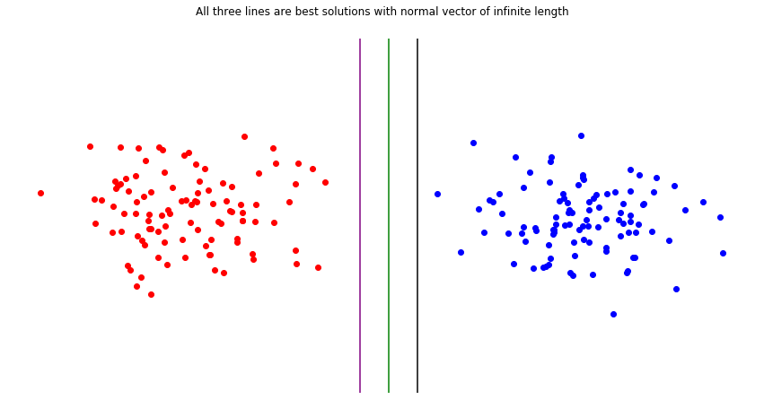

## Regularization

Add $\frac{\lambda}{2}\left \Vert w \right \Vert ^2$ to the loss function

$$Loss = \left(-\sum_{n=1}^N\sum_{m=1}^M t_{nm}\ln(y_{nm})\right) + \frac{\lambda}{2}\left \Vert w \right \Vert ^2$$

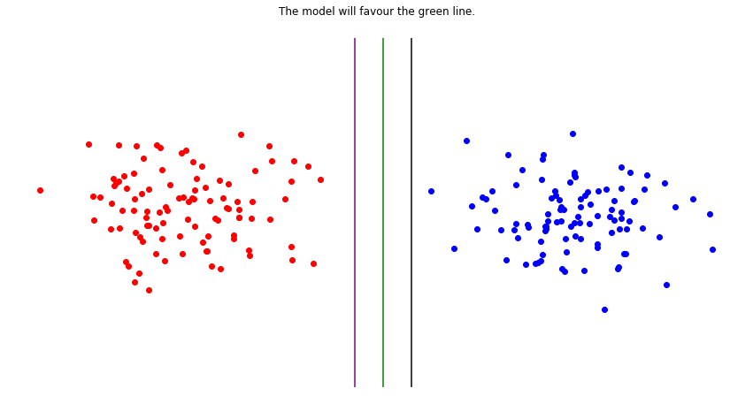

The model will favour the green line.

Q: Why?

A: The loss is convex, so for any $w_1$ and $w_2$ solutions, $\frac{(w_1 + w_2)}{2}$ is better solution than $w_1$ or $w_2$.

Q: Why did this not work without regularizaiton.

A: Big weights cause absence of unique minimum.

Let's see what are units of measurments of our parameters.

$$y_n = \sigma(w_1\cdot \phi_1 + \ldots + w_D\cdot \phi_D)$$

If $\phi_1$ is measured in meters and $\phi_D$ is measured in years.

Q: What are units of measurements of $w_1$ and $w_d$?

A: $y_n$ is probability, so it should be a scalar. So $w_1\phi_1$ is scalar too. Thus $w_1$ is measured in $meters^{-1}$ and $w_d$ in $years^{-1}$

When predicting house price using linear regression: $$y_n=w_1\phi_1 + \ldots + w_D\phi_D$$

For the same $\phi$ measurement units: $\phi_1$ is measured in meters and $\phi_D$ is measured in years.

The units of $w_1$ and $w_d$ would be $\frac{dolars}{meters}$ and $\frac{dolars}{years}$ corerspondingly.

When using regularization, what does $\left\Vert w\right\Vert=\sum_{i=1}^Dw_i^2$ mean?

What's its measurment unit?

Let's add a common unit of measurement.

'Cause we know the data, we can tell which values are high and which are low.

So we can define the 1 by the new unit as highest value and 0 as the lowest value.

Now features are comparable(more or less).

To do this:

$$\phi'_{nd} = \frac{\phi_{nd} - Min[\phi_{nd}]}{Max[\phi_{nd}] - Min[\phi_{nd}]}$$

This will map from $[Min, Max]$ to $[0, 1]$.

Problems:

- outliers may significantly change the results.
- it was no probabilistic meaning.

Standartization: $$\phi_{nd} = \frac{\phi_{nd} - E_n[\phi_nd]}{std_n(\phi_{nd})}$$

We need to:

- find scaling and centering factors
- apply to data
- fit model
- apply scaling on test data before predicting

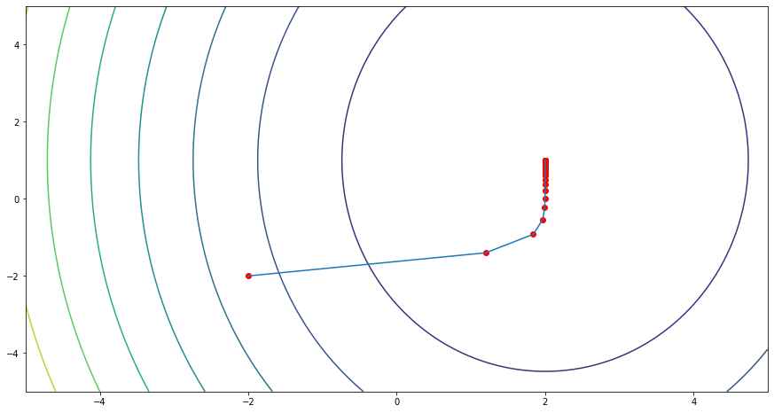

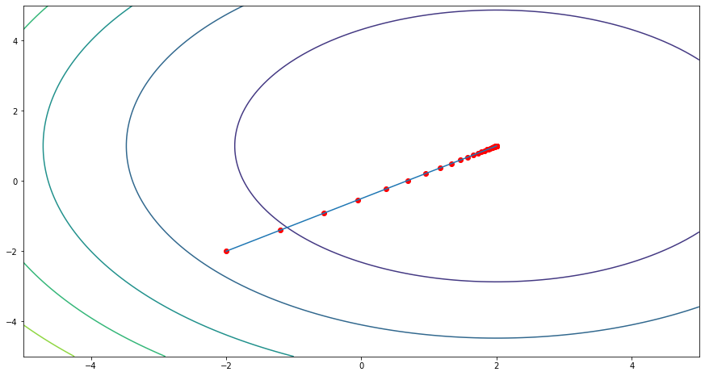

Q: is there models, for which scaling won't make any difference.